# Introduction to rESEF

# 0 Introduction

In the recent years the European Single Electronic Standard (ESEF) was introduced by the European Securities and Markets Authority (ESMA). According to the mandate, all annual financial reports of issuers within scope must be prepared in EXtensible HyperText Markup Language(XHTML) format. The data within the report must be tagged with eXtensible Business Reporting Language (XBRL) tags, embedded into the XHTML documents using Inline XBRL technology. The tags should be based on the ESEF taxonomy, which is largely based on the International Financial Reporting Standards (IFRS) taxonomy published by the IFRS Foundation but with some additions on behalf of ESMA.

The main goal of **rESEF** is to automise the process of retrieval of the aforementioned tagged financial data. With the use of rESEF, the reliance on external sources (such as Bloomberg and Refinitiv) and on manual data extraction can be reduced, such that up-to-date, high-quality data can be obtained as soon as the reports are published by the respective issuers.

Furthermore, rESEF contains functions and (S3) methods for computation of certain financial ratios (EBITDA margin, return on equity, price-to-book, price-to-earnings, enterprise value to sales) and provision of data tagged with specific tags.

# 1 Usage

## 1.1 Set-up

The package utilises a number of R packages, but only imports selected functions from each of them. It is assumed that the required packages are installed. Otherwise, run the following command before loading in the package:

```r
# set wd appropriately
devtools::install(pkg = "rESEF",
                  dependencies = c("Imports", "Depends", "Suggests"))
```

Now, load in the package:

```r
library(rESEF)
```

## 1.2 Extracting information from ESEF reports

The main function within the package is `load_reports`. It extracts information from all HTML and XHTML files (corresponding to annual financial reports in ESEF format) within a given directory.

Two inputs must be supplied:

1. `path`: character string; the path to the directory, where XHTML/HTML files, corresponding to ESEF annual financial reports of a sample of companies, are stored.
   - It is recommended that the user ensures that there are no XHTML/HTML files which do not correspond to annual financial reports in ESEF format within the directory.
   - Usually, when ESEF reports are downloaded, all files corresponding to a single report are compressed into a .zip file. The user must uncompress the relevant files before running the function.
   - The XHTML/HTML files can be stored in the directory as either standalone files or else within subdirectories.
2. `year`: character or numeric; the starting year of the reporting period of interest.

There are two additional inputs which may be specified but have default values:

3. `save.texts`: logical; if `TRUE`, all visible text within the reports will be extracted and saved into a ‘rSEEF_list_texts’ class object, within the ‘rESEF_list’ class object returned by the function.
   - By default, `save.texts = FALSE` to save time and memory when loading in the reports.
4. `verbose`: logical; if `TRUE`, descriptive messages about the progress of the loading process are returned.

For the example considered in the vignette we did the following:

- Download annual financial reports prepared in ESEF format for 2020 in German and/or English for 3 companies, namely Immofinanz AG, Schoeller-Bleckmann Oilfield Equipment AG and Andritz AG.
- Unzip the downloaded .zip files and put them into the same folder. Let `DATA_DIRECTORY_PATH` correspond to the path to this folder.

Now, we are ready to use the package. Load in the reports as follows:

```r
# name the object ATX_sample since we are dealing with a sample of ATX companies
ATX_sample = load_reports(path = DATA_DIRECTORY_PATH,
                          year = 2020,
                          save.texts = TRUE,
                          verbose = FALSE)
```

Note that user’s interaction may be required at the final stage of the loading process. The user may be asked to examine parts of tibbles, containing numeric values for some companies. This happens when an unknown or no format is provided for some values. The user is asked to examine a tibble of some or all of such values and type ‘1’, if “comma formatting” should be applied (i.e. if the user believes that comma is used as a decimal operator), or ‘2’, if “dot formatting” should be applied (i.e. if the user believes that dot is used as a decimal operator). Both values are to be provided as numeric. More details on formatting to be provided in Section 2 (see section 4.1 of https://www.xbrl.org/guidance/ixbrl-tagging-features/ to understand what ‘format’ means in our context).

Let’s consider the output. The object `ATX_sample` is of class ‘rESEF_list’. It has three ‘elements’: an object of class ‘rESEF_list_facts’, an object of class ‘rESEF_list_texts’ and a list with the name “inputs”. If `save.texts` was set to `FALSE`, `ATX_sample` would not contain a ‘rESEF_list_texts’ object. In the following code chunk we demonstrate how to access these objects:

```r
class(ATX_sample)
```

```
## [1] "rESEF_list"
```

```r
ATX_sample_facts = ATX_sample[["facts"]]
class(ATX_sample_facts)
```

```
## [1] "rESEF_list_facts"
```

```r
ATX_sample_texts = ATX_sample[["texts"]]
class(ATX_sample_texts)
```

```
## [1] "rESEF_list_texts"
```

```r
ATX_sample_inputs =  ATX_sample[["inputs"]]
class(ATX_sample_inputs)
```

```
## [1] "list"
```

The three object classes defined in rESEF (‘rESEF_list’, ‘rESEF_list_facts’ and ‘rESEF_list_texts’) are essentially nested lists, meaning that all functions which work on lists can be applied to them. Additionally, there are several S3 methods defined in rESEF (`get_company_names`, `get_value`, `get_ratio`, `get_ratios`) which take an object of one of the three classes as one of their inputs. These will be discussed in detail at a later point.

Furthermore, print and subsetting (with the use of single square brackets) methods have been defined for each of the three classes. These work as follows:

```r
# -- printing methods --

# - 'rESEF_list' -

ATX_sample
## 'rESEF_list' class object
##
## Number of companies:  3
## Languages of reports: de, en
## Texts available:  Yes

# - 'rESEF_list_facts' -

ATX_sample_facts
## 'rESEF_list_facts' class object
##
## Number of companies:  3
## Languages of reports: de, en

# - 'rESEF_list_texts' -

ATX_sample_texts
## 'rESEF_list_texts' class object
##
## Number of companies:  3
## Languages of reports: de, en

# -- subsetting methods --

# - 'rESEF_list' -

# remove the 'rESEF_list_texts' object from ATX_sample, keep the rest
ATX_sample[c(1,3)]
## 'rESEF_list' class object
##
## Number of companies:  3
## Languages of reports: de, en
## Texts available:  No

# class is preserved
class(ATX_sample[c(1,3)])
```

```
## [1] "rESEF_list"
```

```r
# - 'rESEF_list_facts' -

# retain information for the first 2 out of the 3 companies
ATX_sample_facts[1:2]
## 'rESEF_list_facts' class object
##
## Number of companies:  2
## Languages of reports: de, en

# class is preserved
class(ATX_sample_facts[1:2])
```

```
## [1] "rESEF_list_facts"
```

```r
# - 'rESEF_list_texts' -

# retain information for the first 2 out of the 3 companies
ATX_sample_texts[1:2]
## 'rESEF_list_texts' class object
##
## Number of companies:  2
## Languages of reports: de, en

# class is preserved
class(ATX_sample_texts[1:2])
```

```
## [1] "rESEF_list_texts"
```

Note the differences in the printed outputs.

Let’s consider each of the objects constituting `ATX_sample` in turn. We start off with `ATX_sample_facts`, the ‘rESEF_list_facts’ object defined above.

The entries of the ‘rESEF_list_facts’ object are lists, which are named after companies. But what is the correct way to access these lists?

A special function called **`get_company_names`** should be used. This function has 3 associated methods which correspond to the three rESEF classes. In each case a character vector is returned, the entries of which correspond to the names of the companies, for which information is available in the supplied object.

```r
company_names = get_company_names(ATX_sample_facts)
company_names
```

```
## [1] "IMMOFINANZ AG"
## [2] "Schoeller-Bleckmann Oilfield Equipment AG"
## [3] "ANDRITZ AG"
```

The function `get_company_names` is not only useful for accessing nested objects, but also if we would like to get an overlook of all the companies for which information is available within a ‘rESEF_list’, ‘rESEF_list_facts’ or ‘rESEF_list_texts’ object.

Now that we know how to use `get_company_names`, we return to the accessing procedure. Let’s focus on the first company in the list - Immofinanz AG. To access its associated list, we can either use its name (as returned by `get_company_names`) or the numeric index corresponding to its position in `ATX_sample_facts`. Its list can be accessed as follows:

```r
# 1. use company name
company = company_names[1]
company_list = ATX_sample_facts[[company]]

# 2. use numeric index corresponding to position in ATX_sample
company_list = ATX_sample_facts[[1]]

class(company_list)
```

```
## [1] "list"
```

This list has a set of lists as its elements, named after languages of the reports extracted for this company.

```r
# languages of the reports extracted for this company
lang = names(company_list)
lang
```

```
## [1] "de" "en"
```

```r
class(company_list[lang[1]])
```

```
## [1] "list"
```

```r
class(company_list[lang[2]])
```

```
## [1] "list"
```

These lists hold the tagged numeric value information (in the form of tibbles, from now on referred to as facts tibbles), extracted from the corresponding reports.

```r
# tibble of tagged numeric values extracted from the German version of
# the report
tb_facts_de = company_list[[lang[1]]]
head(tb_facts_de)
```

```
## # A tibble: 6 x 13
##   name                company identifier ticker startDate endDate Date
##   <chr>               <chr>   <chr>      <chr>  <date>    <date>  <date>
## 1 ifrs-full:Investme~ IMMOFI~ 5299000DU~ IIA.VI NA        NA      2020-12-31
## 2 ifrs-full:Investme~ IMMOFI~ 5299000DU~ IIA.VI NA        NA      2019-12-31
## 3 ifrs-full:Investme~ IMMOFI~ 5299000DU~ IIA.VI NA        NA      2020-12-31
## 4 ifrs-full:Investme~ IMMOFI~ 5299000DU~ IIA.VI NA        NA      2019-12-31
## 5 ifrs-full:OtherPro~ IMMOFI~ 5299000DU~ IIA.VI NA        NA      2020-12-31
## 6 ifrs-full:OtherPro~ IMMOFI~ 5299000DU~ IIA.VI NA        NA      2019-12-31
## # ... with 6 more variables: explicitMember1_dimension <chr>,
## #   explicitMember1_text <chr>, explicitMember2_dimension <chr>,
## #   explicitMember2_text <chr>, currency <chr>, value <dbl>
```

```r
# tibble of tagged numeric values extracted from the English version of
# the report
tb_facts_en = company_list[[lang[2]]]
```

In general, tibbles for several languages for the same company would differ only in the “name” column, where tags defined by the issuer him-/herself would have several translations. If there are differences in the other columns, it is possible that mistakes were made by the issuer and the reports could contradict each other. Note that for computation of ratios the values tagged with issuer’s own tags are ignored, as they should be either wider or narrower than the ESEF taxonomy elements in accounting meaning or scope (see https://www.xbrl.org/guidance/esef-rules-anchoring-extensions/ and Section 1.4 for details).

What are the columns and their contents?

| Column name | Data type | Description |
| --- | --- | --- |
| “name” | <chr> | tag name |
| “company” | <chr> | company name |
| “identifier” | <chr> | LEI number of the company |
| “ticker” | <chr> | ticker of the company on the Viennese Stock Exchange |
| “startDate” | <date> | start date for the period (if the value refers to a period) |
| “endDate” | <date> | end date for the period (if the value refers to a period) |
| “Date” | <date> | single date (if the value refers to a single point in time) |
| “currency” | <chr> | currency |
| “value” | <dbl> | value in **units** of currency |

Additionally, there are one or more “explicitMember_dimension” and “explicitMember_text” columns, providing details (if any are specified) about the nature of the tagged values (e.g. for the “ifrs-full:Equity” tag, the “explicitMember_text” column(s) may specify if the tagged value is related to issued capital, retained earnings, etc.).

The tag and currency names are not stripped of their namespaces (eg. “ifrs-full:”, “iso4217:”) as these namespaces are needed in order to ensure that the correct values are used in ratio computations.

The LEI numbers are extracted directly from the reports and are connected to the corresponding tickers via the `COMPANY_IDS` data frame in `CONST`, the dataset of constants used in the package.

```r
CONST$COMPANY_IDS
```

```
##    yahoo_symbol                  LEI
## 1       ANDR.VI 549300VZKC61IR5U8G96
## 2        ATS.VI 529900EVOKN4LCCD9321
## 3         BG.VI 529900S9YO2JHTIIDG38
## 4        CAI.VI 5299003ICAPV07J0R180
## 5        DOC.VI 5299002NFQKOBT1E8569
## 6        EBS.VI PQOH26KWDF7CG10L6792
## 7        EVN.VI 529900P4JZBFEVNEAE60
## 8        IIA.VI 5299000DUMZ99SBBX121
## 9        LNZ.VI 529900BKFJBI0QRDJH63
## 10       MMK.VI 5299001AMHDLKUM80611
## 11      POST.VI 529900MVUWACNUTK8467
## 12       OMV.VI 549300V62YJ9HTLRI486
## 13       RBI.VI 9ZHRYM6F437SQJ6OUG95
## 14       SPI.VI 5299001QKV44IT3WPL26
## 15       SBO.VI 549300ZD9ED8GSG3JW36
## 16       UQA.VI 529900OOW8ELHOXWZP82
## 17       VER.VI 5299006UDSEJCTTEJS30
## 18       VIG.VI 549300JCRU23I1THU176
## 19       VOE.VI 529900ZAXBMQDIWPNB72
## 20       WIE.VI 529900VXIFBHO0SW2I31
```

The connections for ATX companies only are documented. The user must update the data frame (by making relevant changes in the CONST.R file, one of the files making up the package, and cleaning and rebuilding the package) if (s)he wishes to consider companies outside of ATX.

Now, let’s consider `ATX_sample_texts`, our ‘rESEF_list_texts’ object.

The structure of `ATX_sample_texts` is very similar to that of `ATX_sample_facts`. The only difference is that one finds character strings of visible text extracted from the corresponding reports instead of the facts tibbles. These strings are to be accessed analogously to the facts tibbles.

Lastly, the ‘inputs’ list contains information on some of the inputs (`path` and `year`) used to load in the reports. This could be convenient when one would like to compare sets of reports from different years.

```r
ATX_sample_inputs$year
```

```
## [1] 2020
```

## 1.3 Filter for specific values

We can use the function **`get_value`** to filter facts tibbles for values tagged with specific tags. The function takes the following inputs:

1. `object`: object of class ‘rESEF_list’ or ‘rESEF_list_facts’; error occurs if ‘rESEF_list’ does not contain a ‘rESEF_list_facts’ object.
2. `company`: character or numeric; the company’s name, as returned by `get_company_names`, or the position of the company in the ‘rESEF_list_facts’ object corresponding to the supplied object, respectively.
3. `tag`: character vector; the tag(s) of interest.
4. `year`: character or numeric; year for the period or the single date to which the value(s) should correspond.

The user must supply the tags together with their corresponding namespaces e.g. “ifrs-full:Equity”. The tibbles returned are subsets of the facts tibbles stored within the corresponding ‘rESEF_list_facts’ objects.

It is important to note, that the function also filters for period as follows:

- if the value corresponds to a period, it requires the start date to be in January of the requested year and the end date to be in December of the requested year,
- if the value corresponds to a single date, it requires the date to be in December of the requested year.

If no filtering for period is required, the user is encouraged to make use of the functionalities of the **dplyr** package to filter the tibbles his/her own way.

```r
Revenue2019 = get_value(object = ATX_sample,
                        company = 1,
                        tag = "ifrs-full:Revenue",
                        year = 2019)

Revenue2019[, c("name", "startDate", "endDate", "value")]
```

```
## # A tibble: 1 x 4
##   name              startDate  endDate        value
##   <chr>             <date>     <date>         <dbl>
## 1 ifrs-full:Revenue 2019-01-01 2019-12-31 366660000
```

```r
Revenue2020 = get_value(object = ATX_sample,
                        company = 1,
                        tag = "ifrs-full:Revenue",
                        year = 2020)

Revenue2020[, c("name", "startDate", "endDate", "value")]
```

```
## # A tibble: 1 x 4
##   name              startDate  endDate        value
##   <chr>             <date>     <date>         <dbl>
## 1 ifrs-full:Revenue 2020-01-01 2020-12-31 377701000
```

```r
Equity2019 = get_value(object = ATX_sample,
                       company = 1,
                       tag = c("ifrs-full:EquityAttributableToOwnersOfParent",
                               "ifrs-full:NoncontrollingInterests"),
                       year = 2020)

Equity2019[, c("name", "Date", "value")]
```

```
## # A tibble: 2 x 3
##   name                                         Date            value
##   <chr>                                        <date>          <dbl>
## 1 ifrs-full:EquityAttributableToOwnersOfParent 2020-12-31 3107583000
## 2 ifrs-full:NoncontrollingInterests            2020-12-31  -23876000
```

## 1.4 Compute financial ratios

Lastly, we can compute a number of financial ratios, based on the values extracted from the reports. For this, one should make use of the function **`get_ratio`**, if a ratio value for one company is required, and **`get_ratios`**, if some ratio values are needed for several companies.

The two functions share most of the inputs:

1. `object`: object of class ‘rESEF_list’ or ‘rESEF_list_facts’; error occurs if ‘rESEF_list’ does not contain a ‘rESEF_list_facts’ object.
2. `ratio`: character; ratio to be computed; takes on one of the following values:
   - “EBITDA_margin” (EBITDA margin),
   - “ROE” (return on equity),
   - “PE” (price-to-earnings),
   - “PB” (price-to-book),
   - “EVSales” (enterprise value to sales).
3. `year`: character or numeric; the ratio is calculated for the end of this year.
4. `date`: character; only needed in the case of the share price dependent ratios (“PE”, “PB”, “EVSales”), ignored for other ratios; to be supplied in the format “YYYY-MM-DD”; set to `as.character(Sys.Date())` by default.

For the `get_ratio` function, one needs to also supply a value for `company`. We refer the reader to Section 1.3 for details.

What form does the output take? A tibble with the following columns is returned:

- “company” - company name
- “year” - year requested
- “ratio” - ratio requested
- “value” - value of ratio computed

In the case of the share price dependent ratios (“PE”, “PB”, “EVSales”), there are 2 extra columns:

- “date_requested” - date, closing price of which was requested to be used for computation
- “date_used” - date, closing price of which was used for computation

The need for the last pair is justified by closing prices not always being available for particular dates e.g. if the requested date is too close to the present day.

The following details should be noted:

- NA values are returned in the “value” and “date_used” column if relevant information could not be extracted from the report.
- The user can only request one kind of ratio to be computed at a time.

In the course of our analysis of the 2020 ATX reports, we observed that NA values are unfortunately frequent. ESMA states that where “the issuer prepares IFRS consolidated financial statements, it shall mark up these IFRS consolidated financial statements using the XBRL markup language”, but nevertheless many numerical values:

- are left untagged (for example, in the case of numbers of shares outstanding), since many important values occur within the text of the report or else within “secondary” statements, or
- are tagged with an own tag; such values are ignored for ratio computations, as further analysis of the tag description by a human reader would be required.

```r
get_ratio(object = ATX_sample,
          company = 1,
          ratio = "EBITDA_margin",
          year = 2020)
```

```
## # A tibble: 1 x 4
##   company        year ratio         value
##   <chr>         <dbl> <chr>         <lgl>
## 1 IMMOFINANZ AG  2020 EBITDA_margin NA
```

```r
get_ratios(object = ATX_sample,
          ratio = "ROE",
          year = 2020)
```

```
## # A tibble: 3 x 4
##   company                                    year ratio   value
##   <chr>                                     <dbl> <chr>   <dbl>
## 1 IMMOFINANZ AG                              2020 ROE   -0.0551
## 2 Schoeller-Bleckmann Oilfield Equipment AG  2020 ROE   NA
## 3 ANDRITZ AG                                 2020 ROE    0.168
```

# 2 Data pipeline

Now that we have shown the possible uses of rESEF, we expand on the thought process behind the construction of the so-called data pipeline, i.e. we answer the question of how one can go from the zipped files constituting the issuers’ ESEF report and taxonomy files to computation of ratios based on the information extracted from these files.

## Loading in reports

The function `load_reports` takes the given path and considers each file/directory within the corresponding directory, one at a time. If there is one or more HTML or XHTML file(s) corresponding to a file/directory, their paths are taken one at a time and the corresponding files are read in as xml files and stored as objects of class ‘xml_document’.

The node with the name “NameOfReportingEntityOrOtherMeansOfIdentification” (a mandatory tag) is found within the ‘xml_document’ object. It contains the name of the company, as well as the value of the “contextRef” attribute. This value is the value of the “id” attribute of the node (whose node name is “context”), which contains information on the reporting period (start and end dates). If the year of the start and end dates is the same as the requested year, we do further work with the ‘xml_document’ object. Otherwise, we throw it out and move on to the next file/directory within the provided directory.

For each of the files with correct reporting period, the following is done.

1. *Extract all information*

   First, we discuss how all the needed information is extracted.
- All the nodes within the ‘xml_document’ object are found and stored, as well as the names of all the unique attributes, whose values are used to provide description for these nodes.
- A large tibble is created, which stores information for each node within the report. The column names are the unique attribute names within the report. If some attribute’s value is not specified for the node, an NA appears in the respective row (node) and column (attribute). Additionally, there is a column called “text”. All of the text nested within a node is saved in the corresponding cell. These text values are only used internally.
- A subset of this “report tibble” is selected by filtering for all nodes with the node name “nonFraction”. All tagged numerical values are stored as text within these nodes. Additionally, the attributes and their values describe what tag was used, how the value is formatted and scaled, what the sign of the value is, etc. We call these subtibbles “facts tibbles”. They are stored as separate objects from now on.
- The “nonFraction” nodes often have “contextRef” and “unitRef” values. These point to other nodes, with node names “context” and “unit”, respectively. Within these nodes, the information on the periods and currencies (eg. EUR vs EUR per share) corresponding to the values is stored. For the “context nodes”, a list of tibbles is created, with a tibble for each node. These will later be used to produce the final tibble, returned by the function.
- If the user wishes to save texts as well, the node with the name “body” is found. There are usually many nodes which are children of this node. The nodes whose text is not displayed are ignored. The texts for all other children are collapsed appropriately into a single character string. These character strings will be returned by the function.
2. *Append or not?*

   Suppose there are several XHTML files for the same company and in the same language. We want to append the corresponding objects (whose creation was described above) only once. How can we do that?
- Apart from the period information, the “context” nodes also store the LEI identifier value for each company.
- We check if the identifier-language combination has already occurred. If it did, then the objects are thrown out and we move on to the next file. Otherwise, the 4 objects (“report tibble”, “facts tibble”, list of “context tibbles”, report text string) are attached to 4 separate lists.

  Once the above steps have been completed for all (X)HTML files within the supplied directory, a new list is created which holds the 4 lists.
3. *Putting “facts tibbles” into their final form*

   Now that we have the information for all of the companies, we need to “connect the dots”. We alter the “facts tibbles” by using the additional information related to the “nonFraction” nodes which is stored in the other objects (“report tibbles” and lists of “context” tibbles).
- The LEI number of the company is stored within each “context” node and,hence, easily extracted.
- In order to connect the company to a ticker, the LEI number is matched to a ticker through the `CONST$COMPANY_IDS` data frame (already discussed in Section 1), which needs to be maintained by the user and originally contains correspondences for the ATX companies only.
- The periods are filled out by matching the “nonFraction” nodes to their “context” nodes through “contextRef”. The “context” nodes sometimes store further description of the nature of the value (e.g. whether a value tagged as equity refers to issued capital, retained earnings etc.). This information is also extracted and used to fill the “explicitMember_dimension” and “explicitMember_text” columns (discussed in Section 1).
- The currencies are filled out by matching the “nonFraction” nodes to their “unit” nodes through “unitRef”.
- Appropriate formatting methods are applied to the numerical values, as specified by the “format” attribute. As the transformation registry for XBRL tagging is regularly updated, the user needs to update the formatting methods in use by changing `CONST` data appropriately.
- The values are scaled (according to the “scale” attribute values) and appropriate signs are applied.
- Lastly, columns which are no longer needed (e.g. “format”, “column”, “scale”) are removed.
4. *New classes*

   The altered “facts tibbles” are nested within a single list, the class of which is defined to be ‘rESEF_list_facts’. The text character strings are nested within another list of class ‘rESEF_list_texts’. A new list is created to hold the 2 lists and assigned the class ‘rESEF_list’. “Report tibbles” and lists of “context” tibbles are thrown out as we no longer need them.

## Values and ratios

The function `get_value` simply filters the tibbles for the right name/names (tag/tags), as well as the period (discussed in Section 1.3).

The workings of `get_ratio` and `get_ratios` functions are less straight-forward.

- An inner function, analogous to `get_value` is defined to retrieve end-of-period values or values corresponding to the whole January - December period.
- For each ratio there are several values which are used for computation. For each of such values, a more complex variant of the inner function discussed above is defined, which attempts to use the formulas connecting the relevant IFRS taxonomy elements in order to retrieve the needed value.

  For example, suppose we need the value tagged with “ifrs-full:OtherFinancialLiabilities”, but this tag is not used. Instead, we can look for values tagged with “ifrs-full:OtherCurrentFinancialLiabilities” and “ifrs-full:OtherNoncurrentFinancialLiabilities” and sum the corresponding values up if they are present. All such formulas are defined in IFRS formula linkbases (found within IFRS taxonomy file collections). One needs to note that different taxonomies may use different labels and formulas. As these may change in the future, the functions would need to be adjusted accordingly.

Report issuers are also allowed to use their own tags if the value they want to tag does not match any of the core IFRS taxonomy elements. Unfortunately, we have to ignore these values, as by the current ESMA regulations require these to be either wider or narrower in the accounting meaning and scope than the IFRS taxonomy elements.

For the share price dependent ratios, the prices are fetched from the API of Yahoo Finance.

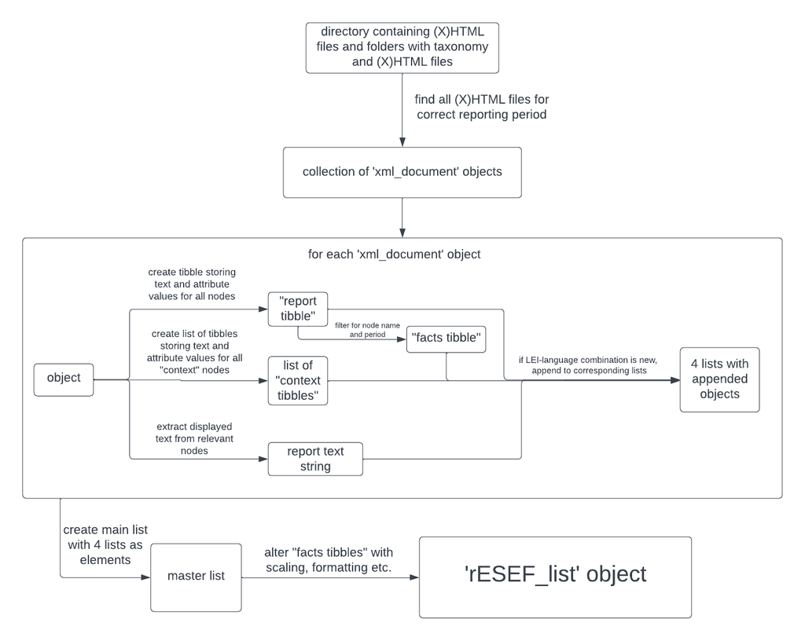

# 3 Case study - ATX company comparison

For the following case study, we loaded in the annual financial reports (in ESEF format) of 19 out of 20 companies (constituting ATX during the period 2021-2022) for 2020. For one of the companies (Voestalpine AG), an incorrect date was stated in the field related to the reporting period and, hence, the (X)HTML file was ignored. We saved this object locally as an .Rda file. The object has been loaded in under the name `ATX`.

```r
load(file = "ATX_with_texts.Rda")
ATX
## 'rESEF_list' class object
##
## Number of companies:  19
## Languages of reports: de, en
## Texts available:  Yes

company_names = get_company_names(ATX)
company_names
```

```
##  [1] "IMMOFINANZ AG"
##  [2] "Schoeller-Bleckmann Oilfield Equipment AG"
##  [3] "ANDRITZ AG"
##  [4] "AT & S Austria Technologie & Systemtechnik Aktiengesellschaft"
##  [5] "BAWAG Group"
##  [6] "CA Immobilien Anlagen Aktiengesellschaft"
##  [7] "DO & CO AKTIENGESELLSCHAFT"
##  [8] "EVNAGN AG"
##  [9] "Lenzing Aktiengesellschaft"
## [10] "Mayr-Melnhof Karton AG"
## [11] "Österreichischen Post AG"
## [12] "OMV Aktiengesellschaft"
## [13] "Erste Group Bank AG"
## [14] "Raiffeisen Bank International AG"
## [15] "S IMMO AG"
## [16] "UNIQA Insurance Group AG"
## [17] "VERBUND"
## [18] "VIENNA INSURANCE GROUP AG Wiener Versicherung Gruppe"
## [19] "Wienerberger"
```

We then proceeded to compare the companies on the basis of their financial ratio values and the relative frequencies of ESG words constituting their reports.

## 3.1 Financial ratios

Suppose we ask ourselves the question: what is the value of automising the process? For example, assume that 5 out of 20 ATX companies publish in May, while the other 15 publish their reports in July. Consider the following two scenarios:

- We update the values and financial ratios for the 5 companies in May and keep the old ones for the other 15 companies. We then proceed to invest into the “best” subset of companies in May.
- We wait until July when all reports are in and update all the values and ratios at the same time. We then invest into the “best” subset of companies in July.

Obviously, with the scarcity of values obtained the task becomes chaotic. Our hope was that we would be able to compute all of the financial ratios considered for the 20 ATX companies, with all required values obtained directly from the reports. Although the value is limited, we still wanted to see whether a profitable financial decision could be made.

First, we identify combinations of ratios which can be computed for the largest number of our companies, both for 2019 and 2020 (as the non-updated values should be based on the 2019 reports). It turns out that the ROE (return-on-equity) and P/E (price-to-earnings) combination is the most “popular”, if we assume that ROE values for 2019 are readily available, since the values needed for 2019 ROE computations are generally not found in the 2020 reports. Assuming this, 2019 and 2020 ROE and P/E values are available for a subset of 8 companies. The names and publishing dates of the companies are highlighted through the use of italic font in the following table.

[output not shown]

- Suppose we have the following “report-review” dates: 1st April, 1st May, 1st June and 1st July (2021).
- For each of these dates, we make 2 tibbles:
  - one, where we update some values if the publishing date was earlier than the “report-review” date, and
  - another, where for all ratios we use the values from last year, i.e. we do not sit down to review reports until July, when (almost) all of them are in.
- Each company within each tibble receives a “rank” for each of the ratios. We take the simplistic view that the higher the ROE and the lower the P/E is, the better the performance of the company. The “ROE_rank” of the company with the highest ROE would then be 8 and the “ROE_rank” of the company with the lowest ROE would be 1. Analogous ranking is applied for P/E.
- The ranks are then summed to give the “total rank” and one half of the companies with highest total ranks are invested into, a) in proportion to the values of the total rank and b) in equal proportions.
- This is done for both updated and not updated tibbles and scatterplots are used to show the performance of the two portfolios over time.

We make use of *dplyr*, *lubridate*, *purrr* packages to construct the portfolios and compute their values, as well as *ggplot2* and *gridExtra* for plotting.

```r
library(dplyr)
library(lubridate)
# subset of companies
company_subset = company_names[c(1,3,6,12,13,14,17,19)]
company_subset

# number of companies in the subset
n = 8

# corresponding 'rESEF_list_facts' object
ATX_subset_facts = ATX[["facts"]][company_subset]

# tickers for company subset
tickers =
  sapply(ATX_subset_facts,
         function(company_list) unique(company_list[[1]][["ticker"]]))

# ROE values for 2019
ROE2019 = c(0.123, 0.101, 0.140, 0.135, 0.092, 0.094, 0.099, 0.124)

# create the updated and not updated tibbles
tb_upd = tibble(company = rep(company_subset, 4),
                ticker = rep(tickers, 4),
                publishing_date = as.Date(
                  rep(c("2021-04-22", "2021-03-03",
                        "2021-03-24", "2021-03-25",
                        "2021-03-26", "2021-03-17",
                        "2021-04-17", "2021-03-29"), 4)),
                # "report-review" dates
                date = as.Date(c(rep("2021-04-01", 8),
                                 rep("2021-05-01", 8),
                                 rep("2021-06-01", 8),
                                 rep("2021-07-01", 8))),
                ROE = NA,
                PE = NA)

tb_not_upd = tb_upd


# fill in the tibbles
fill_in_values = function(tb, update, ratio){

  company_seq = tb[["company"]]
  date_seq = tb[["date"]]
  publishing_date_seq = tb[["publishing_date"]]

  if (update){
    year_seq = ifelse(date_seq < publishing_date_seq, 2019, 2020)
  }else{
    # 4 report review dates, 8 companies
    year_seq = rep(2019, 4 * 8)
  }

  tb[ratio] =
    unlist(
      sapply(1:(4*8), simplify = FALSE,
             function(i){
               if (ratio == "ROE" & year_seq[i] == 2019){
                 rep(ROE2019, 4)[i]
               }else{
                 tmp = get_ratio(object = ATX_subset_facts,
                                 company = company_seq[i],
                                 ratio = ratio,
                                 year = year_seq[i],
                                 date = date_seq[i])
                 tmp[["value"]]
               }
             }
             )
      )
  tb
}

# - first, tibble without updates
tb_not_upd =
  fill_in_values(tb = tb_not_upd, update = FALSE, ratio = "ROE")
tb_not_upd =
  fill_in_values(tb = tb_not_upd, update = FALSE, ratio = "PE")


# - now, tibble with updates
tb_upd =
  fill_in_values(tb = tb_upd, update = TRUE, ratio = "ROE")
tb_upd =
  fill_in_values(tb = tb_upd, update = TRUE, ratio = "PE")

# helper functions

# - create ranks as described earlier
create_ranks = function(tb, n){

  tb = tb %>% arrange(desc(ROE))
  tb["ROE_rank"] = n : 1

  tb = tb %>% arrange(PE)
  tb["PE_rank"] = n : 1

  tb["rank"] = tb["ROE_rank"] + tb["PE_rank"]
  tb = tb %>% arrange(desc(rank))
  tb
}

# - fetch prices from yahoo
prices = function(date, tickers){

  date_lower = date - 10
  date_upper = date + 1

  suppressWarnings(
    unlist(
      sapply(tickers, simplify = FALSE,
             function(ticker){
               prices_ = tq_get(ticker,
                                from = as.character(date_lower),
                                to = as.character(date_upper),
                                get = "stock.prices")
               prices_[[nrow(prices_), "close"]]
           }
           )
      )
    )
}




# - compute portfolio value, given date, company tickers and weights (numbers of shares)
portfolio_value = function(weights, tickers, date){

  return(sum(prices(date, tickers) * weights))
}

# main function
portfolio_values = function(tb_upd, tb_not_upd, date, amount, n){

  date = as.Date(date)

  tb_upd = tb_upd[tb_upd[["date"]] == date, ]
  tb_not_upd = tb_not_upd[tb_not_upd[["date"]] == date, ]

  tb_upd = create_ranks(tb_upd, n)
  tb_not_upd = create_ranks(tb_not_upd, n)

  tickers_upd = pull(tb_upd[1:floor(n/2), "ticker"])
  tickers_not_upd = pull(tb_not_upd[1:floor(n/2), "ticker"])

  prices_upd = prices(date, tickers_upd)
  prices_not_upd = prices(date, tickers_not_upd)


  weights_upd = sapply(1:floor(n/2), function(i){
    (tb_upd[["rank"]][i] / sum(tb_upd[["rank"]][1:floor(n/2)]) * amount) /
      prices_upd[i]})
  weights_not_upd = sapply(1:floor(n/2), function(i){
    (tb_not_upd[["rank"]][i] / sum(tb_not_upd[["rank"]][1:floor(n/2)]) * amount) /
      prices_not_upd[i]})

  # first dates corresponding to next 6 months
  dates = purrr::reduce(lapply(0:6, function(i) date %m+% period(i, "month")), c)

  tibble(
    date = dates,
    updated_portfolio_value =
      sapply(dates, function(date) portfolio_value(weights_upd, tickers_upd, date)),
    not_updated_portfolio_value =
      sapply(dates, function(date) portfolio_value(weights_not_upd, tickers_not_upd, date))
  )
}

# evolution of values for 2 portfolios
# let initial amount = 10000
amount = 10000

portfolios_apr_21 = portfolio_values(tb_upd, tb_not_upd, date = "2021-04-01", amount, n)
portfolios_may_21 = portfolio_values(tb_upd, tb_not_upd, date = "2021-05-01", amount, n)
portfolios_jun_21 = portfolio_values(tb_upd, tb_not_upd, date = "2021-06-01", amount, n)
portfolios_jul_21 = portfolio_values(tb_upd, tb_not_upd, date = "2021-07-01", amount, n)
```

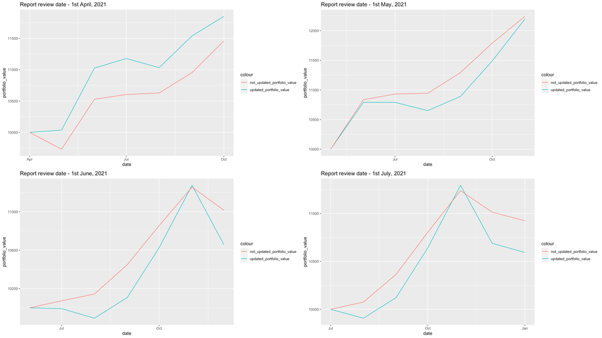

In the majority of the cases, the portfolio based on the 2019 ratios outperforms the portfolio based on the updated ratios. This result is rather disappointing but one has to keep in mind that we are dealing with a very small sample of companies, as well as very few ratios in our analysis. Hence, the results are undoubtedly affected by these limitations. The scarcity of values extracted from the reports is largely at fault. Once can hope that in the future the list of mandatory tags will be expanded by ESMA, such that the package would be able to extract more useful values.

## 3.2 ESG

In this part basic sentiment analysis (SA) methods are used to compute the relative frequencies of ESG related words within the reports of ATX companies. For the analysis of the reports written in English, all terms (482 in total) of the ESG word list, put together by P. Baier et. al (), are used. To conduct SA on the German reports, this list was translated with the use of the DeepL translator (https://www.deepl.com/translator).

Some small adjustments were made to the translated list to account for gendering in the German language, for example, the words “inspector” and “inspectors” were present in the English word list, were translated to “Inspektor” and “Inspektoren” by the DeepL Translator and we added “Inspektorin” and “Inspektorinnen” to the translated list. Additionally, we examine the effect of stemming on the German reports and the translated word list to account for declension in the German language.

We make use of several packages, namely **tm**, **stringr**, **stopwords** and **dplyr** (which we loaded in earlier).

```r
library(stringr)
library(tm)
library(stopwords)
```

The ESG word list is loaded in and available under the name `ESG_words`:

Pre-processing the word list:

```r
# turn all letters into lowercase
ESG_words = apply(ESG_words, 2, tolower)

# remove or replace leading/trailing/multiple whitespaces
ESG_words = apply(ESG_words, 2, str_squish)

head(ESG_words)
```

```
##      X.U.FEFF.en de
## [1,] "approval"  "zulassung"
## [2,] "approvals" "genehmigungen"
## [3,] "approve"   "genehmigen"
## [4,] "approved"  "genehmigt"
## [5,] "approves"  "genehmigt"
## [6,] "approving" "genehmigen"
```

```r
# set of English ESG words
ESG_words_EN = unique(str_subset(ESG_words[, 1], ".+"))

# set of German ESG words
ESG_words_DE = unique(str_subset(ESG_words[, 2], ".+"))
# set of German "ESG stems"
ESG_stems_DE = unique(stemDocument(ESG_words_DE, language = "de"))
```

Let’s begin with the English texts.

```r
# names of companies, for which English reports are available
EN_company_names =
  company_names[sapply(ATX[["texts"]], function(x) "en" %in% names(x))]
EN_company_names
```

```
## [1] "IMMOFINANZ AG"
## [2] "ANDRITZ AG"
## [3] "CA Immobilien Anlagen Aktiengesellschaft"
## [4] "Raiffeisen Bank International AG"
## [5] "UNIQA Insurance Group AG"
## [6] "VERBUND"
## [7] "VIENNA INSURANCE GROUP AG Wiener Versicherung Gruppe"
```

```r
# list of all available English texts
EN_texts = lapply(ATX[["texts"]][EN_company_names],
                  function(company_list) company_list[["en"]])
```

We now check the encodings and throw out texts with “unknown” encoding.

```r
lapply(EN_texts, Encoding)
```

```
## $`IMMOFINANZ AG`
## [1] "UTF-8"
##
## $`ANDRITZ AG`
## [1] "UTF-8"
##
## $`CA Immobilien Anlagen Aktiengesellschaft`
## [1] "UTF-8"
##
## $`Raiffeisen Bank International AG`
## [1] "UTF-8"
##
## $`UNIQA Insurance Group AG`
## [1] "UTF-8"
##
## $VERBUND
## [1] "UTF-8"
##
## $`VIENNA INSURANCE GROUP AG Wiener Versicherung Gruppe`
## [1] "UTF-8"
```

Only “UTF-8” is used and, hence, we do not remove any texts from the list. We now take care of the leading, trailing and multiple whitespaces.

```r
EN_texts = lapply(EN_texts, str_squish)
```

Next, we tokenise the texts, removing punctuation (but keeping intra-word dashes), one-letter terms, numbers and stopwords.

```r
ctrl = list(removePunctuation = list(preserve_intra_word_dashes = TRUE),
             wordLengths = c(2, Inf),
             removeNumbers = TRUE,
             stopwords = TRUE)

# tf_vecs for term-frequency vectors
EN_tf_vecs = lapply(EN_texts, function(text) termFreq(unlist(text), control = ctrl))

class(EN_tf_vecs[[1]])
```

```
## [1] "term_frequency" "integer"
```

But, unfortunately, some new issues arise.

```r
head(EN_tf_vecs[[1]])
```

```
##        -- -meuribor    -month ★★★ ★★★★    aachen
##         1         1         3         1         1         2
```

Some extra cleaning is required. First, we replace all “double-dashes” with single dashes. The “double-dashes” may arise when a text string containing composite words with multiple dashes is tokenised, while having `preserve_intra_word_dashes = TRUE`.

```r
EN_tf_vecs = lapply(EN_tf_vecs, function(tf_vec){
  names(tf_vec) = str_replace_all(names(tf_vec), pattern = "--", replacement = "-")
  tf_vec
})
```

If there are no alphabetic characters in a term, we remove it completely.

```r
EN_tf_vecs =
  lapply(EN_tf_vecs, function(tf_vec){
    # list of matrices of positions of all alphabetic characters within terms
    pos_mats = str_locate_all(names(tf_vec), pattern = "[:alpha:]")
    # if number of rows in a matrix is 0, respective term has no alpha characters
    loc = sapply(pos_mats, function(mat) nrow(mat) == 0)
    # remove such terms
    tf_vec[!loc]
})
```

If there are some alphabetic characters in a term, we remove the special characters at the beginning and/or end.

```r
EN_tf_vecs = lapply(EN_tf_vecs, function(tf_vec){
  names(tf_vec) = str_replace_all(names(tf_vec), pattern = "^\\W+|\\W+$", replacement = "")
  tf_vec
})
```

Lastly, we remove one-letter terms and terms which occur infrequently (once or twice only).

```r
# remove one-letter words
EN_tf_vecs = lapply(EN_tf_vecs,
                    function(tf_vec) tf_vec[!(sapply(names(tf_vec), nchar) == 1)])

# remove infrequent words
EN_tf_vecs = lapply(EN_tf_vecs, function(tf_vec) tf_vec[!(tf_vec == 1 | tf_vec == 2)])
```

We are now ready to compute relative frequencies of the ESG words for the English texts.

```r
ESG_EN =
  tibble(company = names(EN_tf_vecs),
         ESG_perc = sapply(EN_tf_vecs, function(tf_vec){
           sum(tf_vec[which(names(tf_vec) %in% ESG_words_EN)]) / sum(tf_vec) })) %>%
  arrange(desc(ESG_perc))

ESG_EN
```

```
## # A tibble: 7 x 2
##   company                                              ESG_perc
##   <chr>                                                   <dbl>
## 1 VERBUND                                                0.0499
## 2 ANDRITZ AG                                             0.0404
## 3 IMMOFINANZ AG                                          0.0381
## 4 CA Immobilien Anlagen Aktiengesellschaft               0.0309
## 5 VIENNA INSURANCE GROUP AG Wiener Versicherung Gruppe   0.0296
## 6 UNIQA Insurance Group AG                               0.0269
## 7 Raiffeisen Bank International AG                       0.0184
```

Let’s compare the values we obtained against one of RBI’s latest equity recommendation lists (published on February 3, 2022). RBI uses a green leaf indicator to express whether they recommend a stock as an ESG compliant investment or not.

| company | ESG_perc **(in % to 2 d.p.)** | Indicator value |
| --- | --- | --- |
| VERBUND | 4.99 | 🌱 |
| ANDRITZ AG | 4.04 | 🌱 |
| IMMOFINANZ AG | 3.81 |  |
| CA Immobilien Anlagen Aktiengesellschaft | 3.09 |  |
| VIENNA INSURANCE GROUP AG Wiener Versicherung Gruppe | 2.96 | 🌱 |
| UNIQA Insurance Group AG | 2.69 |  |
| Raiffeisen Bank International AG | 1.84 |  |

Overall, there seems to be some positive correlation between RBI’s green leaf indicator and the percentage of ESG words within reports. However, one has to be careful making statements based on this observation, as the sample size is rather small and the reports under consideration are for 2020, while the recommendation list was published almost a year later.

We consider the difference in the sample means without a formal t-test, as it is likely that the distributional assumptions are violated due to a small sample size.

```r
# "green-leaf" companies
sum(ESG_EN[c(1,2,5), 2]) / 3
```

```
## [1] 0.03994975
```

```r
# "non-green-leaf" companies
sum(ESG_EN[-c(1,2,5), 2]) / 4
```

```
## [1] 0.0285773
```

The sample mean for the endorsed companies is almost 1.2% higher than that for the not recommended ones. This is an interesting observation as this could mean that the companies with a stronger (relative to other companies) focus on ESG-related topics are more likely to capture this in their annual financial reports through the use of appropriate vocabulary.

In their publication, P. Baier et. al state that the “results show an average of 4.0 % ESG words on total words in the reports”. Do we observe a similar content?

```r
mean(ESG_EN[["ESG_perc"]])
```

```
## [1] 0.03345121
```

We do, in fact, observe a rather similar value. Hence, the above example provides some evidence in support of the conclusions of the publication also holding for the annual financial reports of European companies.

Lastly, we consider the German reports in our sample. In this case, we provide two sets of results - with and without stemming. The reason why stemming can be useful when it comes to German is the all-around declension of nouns, adjectives, pronouns, etc. We did not add any alternative forms for the terms in the translated word list, apart from occasionally adding nouns for the missing gender as described above.

We do everything analogously to the English report analysis above, but we define an extra column in the final tibble, to get the values for the method which uses stemming in addition to all other pre-processing methods described above.

```r
# names of companies, for which German reports are available
DE_company_names =
  company_names[sapply(ATX[["texts"]], function(x) "de" %in% names(x))]
DE_company_names
```

```
##  [1] "IMMOFINANZ AG"
##  [2] "Schoeller-Bleckmann Oilfield Equipment AG"
##  [3] "ANDRITZ AG"
##  [4] "AT & S Austria Technologie & Systemtechnik Aktiengesellschaft"
##  [5] "BAWAG Group"
##  [6] "CA Immobilien Anlagen Aktiengesellschaft"
##  [7] "DO & CO AKTIENGESELLSCHAFT"
##  [8] "EVNAGN AG"
##  [9] "Lenzing Aktiengesellschaft"
## [10] "Mayr-Melnhof Karton AG"
## [11] "Österreichischen Post AG"
## [12] "OMV Aktiengesellschaft"
## [13] "Erste Group Bank AG"
## [14] "S IMMO AG"
## [15] "UNIQA Insurance Group AG"
## [16] "VERBUND"
## [17] "VIENNA INSURANCE GROUP AG Wiener Versicherung Gruppe"
## [18] "Wienerberger"
```

```r
# list of all available German texts
DE_texts = lapply(ATX[["texts"]][DE_company_names],
                  function(company_list) company_list[["de"]])

# check the encodings and throw out strings with "unknown" encoding
lapply(DE_texts, Encoding)
```

```
## $`IMMOFINANZ AG`
## [1] "UTF-8"
##
## $`Schoeller-Bleckmann Oilfield Equipment AG`
## [1] "UTF-8"
##
## $`ANDRITZ AG`
## [1] "UTF-8"
##
## $`AT & S Austria Technologie & Systemtechnik Aktiengesellschaft`
## [1] "UTF-8"
##
## $`BAWAG Group`
## [1] "UTF-8"
##
## $`CA Immobilien Anlagen Aktiengesellschaft`
## [1] "UTF-8"
##
## $`DO & CO AKTIENGESELLSCHAFT`
## [1] "UTF-8"
##
## $`EVNAGN AG`
## [1] "UTF-8"
##
## $`Lenzing Aktiengesellschaft`
## [1] "UTF-8"
##
## $`Mayr-Melnhof Karton AG`
## [1] "unknown"
##
## $`Österreichischen Post AG`
## [1] "UTF-8"
##
## $`OMV Aktiengesellschaft`
## [1] "UTF-8"
##
## $`Erste Group Bank AG`
## [1] "UTF-8"
##
## $`S IMMO AG`
## [1] "UTF-8"
##
## $`UNIQA Insurance Group AG`
## [1] "UTF-8"
##
## $VERBUND
## [1] "UTF-8"
##
## $`VIENNA INSURANCE GROUP AG Wiener Versicherung Gruppe`
## [1] "UTF-8"
##
## $Wienerberger
## [1] "UTF-8"
```

```r
DE_texts = DE_texts[-which(names(DE_texts) == DE_company_names[10])]

# take care of the leading, trailing and multiple whitespaces
DE_texts = lapply(DE_texts, str_squish)

# tokenise the texts, removing punctuation (but keeping intra-word dashes), one-letter terms, numbers and stopwords
ctrl = list(removePunctuation = list(preserve_intra_word_dashes = TRUE),
             wordLengths = c(2, Inf),
             removeNumbers = TRUE)

# tf_vecs for term-frequency vectors
DE_tf_vecs = lapply(DE_texts, function(text) termFreq(unlist(text), control = ctrl))

# replace all double-dashes with single dashes
DE_tf_vecs = lapply(DE_tf_vecs, function(tf_vec){
  names(tf_vec) = str_replace_all(names(tf_vec), pattern = "--", replacement = "-")
  tf_vec
})

# if there are no alphabetic characters in a term, we remove it completely.
DE_tf_vecs =
  lapply(DE_tf_vecs, function(tf_vec){
    # list of matrices of positions of all alphabetic characters within terms
    pos_mats = str_locate_all(names(tf_vec), pattern = "[:alpha:]")
    # if number of rows in a matrix is 0, respective term has no alpha characters
    loc = sapply(pos_mats, function(mat) nrow(mat) == 0)
    # remove such terms
    tf_vec[!loc]
})

# if there are some alphabetic characters in a term, we remove the special characters at the beginning and/or end
DE_tf_vecs = lapply(DE_tf_vecs, function(tf_vec){
  names(tf_vec) = str_replace_all(names(tf_vec), pattern = "^\\W+|\\W+$", replacement = "")
  tf_vec
})

# remove one-letter words
DE_tf_vecs = lapply(DE_tf_vecs,
                    function(tf_vec) tf_vec[!(sapply(names(tf_vec), nchar) == 1)])

# remove infrequent words
DE_tf_vecs = lapply(DE_tf_vecs, function(tf_vec) tf_vec[!(tf_vec == 1 | tf_vec == 2)])

# remove German stopwords
DE_tf_vecs = lapply(DE_tf_vecs, function(tf_vec){
  tf_vec[!(names(tf_vec) %in% stopwords(language = "de"))]
})

# create list of vectors of stemmed terms
DE_tf_vecs_stem = lapply(DE_tf_vecs, function(tf_vec){
  names(tf_vec) = stemDocument(names(tf_vec), lang = "de")
  tf_vec
})


# compute relative frequencies of the ESG words for the German texts
ESG_DE =
  tibble(company = names(DE_tf_vecs),
         # ESG_perc with no stemming
         ESG_perc = sapply(DE_tf_vecs, function(tf_vec){
           sum(tf_vec[which(names(tf_vec) %in% ESG_words_DE)]) / sum(tf_vec)}),
         # ESG_perc with stemming
         ESG_perc_stem = sapply(DE_tf_vecs_stem, function(tf_vec){
           sum(tf_vec[which(names(tf_vec) %in% ESG_stems_DE)]) / sum(tf_vec)}))
```

First, we consider the results obtained without stemming.

```r
ESG_DE = ESG_DE %>% arrange(desc(ESG_perc))
# results with no stemming
ESG_DE[, c("company", "ESG_perc")]
```

```
## # A tibble: 17 x 2
##    company                                                         ESG_perc
##    <chr>                                                              <dbl>
##  1 "Schoeller-Bleckmann Oilfield Equipment AG"                       0.0266
##  2 "ANDRITZ AG"                                                      0.0251
##  3 "Erste Group Bank AG"                                             0.0249
##  4 "VERBUND"                                                         0.0235
##  5 "EVN\ue01fAGN AG"                                                 0.0232
##  6 "S IMMO AG"                                                       0.0231
##  7 "BAWAG Group"                                                     0.0228
##  8 "VIENNA INSURANCE GROUP AG Wiener Versicherung Gruppe"            0.0223
##  9 "UNIQA Insurance Group AG"                                        0.0221
## 10 "IMMOFINANZ AG"                                                   0.0215
## 11 "CA Immobilien Anlagen Aktiengesellschaft"                        0.0205
## 12 "Österreichischen Post AG"                                        0.0190
## 13 "AT & S Austria Technologie & Systemtechnik Aktiengesellschaft"   0.0187
## 14 "OMV Aktiengesellschaft"                                          0.0176
## 15 "Wienerberger"                                                    0.0175
## 16 "Lenzing Aktiengesellschaft"                                      0.0163
## 17 "DO & CO AKTIENGESELLSCHAFT"                                      0.0156
```

| company | ESG_perc (in % to 2 d.p.) | Indicator value |
| --- | --- | --- |
| Schoeller-Bleckmann Oilfield Equipment AG | 2.66 |  |
| ANDRITZ AG | 2.51 | 🌱 |
| Erste Group Bank AG | 2.49 | 🌱 |
| VERBUND | 2.35 | 🌱 |
| EVNAGN AG | 2.32 |  |
| S IMMO AG | 2.31 |  |
| BAWAG Group | 2.28 | 🌱 |
| VIENNA INSURANCE GROUP AG Wiener Versicherung Gruppe | 2.23 | 🌱 |
| UNIQA Insurance Group AG | 2.21 |  |
| IMMOFINANZ AG | 2.15 |  |
| CA Immobilien Anlagen Aktiengesellschaft | 2.05 |  |
| Österreichischen Post AG | 1.90 | 🌱 |
| AT & S Austria Technologie & Systemtechnik Aktiengesellschaft | 1.87 |  |
| OMV Aktiengesellschaft | 1.76 |  |
| Wienerberger | 1.75 |  |
| Lenzing Aktiengesellschaft | 1.63 |  |
| DO & CO AKTIENGESELLSCHAFT | 1.56 |  |

We note that 5 out of 6 companies end up in the top half of the table. What are the differences in the sample means?

```r
# "green-leaf" companies
sum(ESG_DE[c(2,3,4,7,8,12), 2]) / 6
```

```
## [1] 0.02292833
```

```r
# "non-green-leaf" companies
sum(ESG_DE[-c(2,3,4,7,8,12), 2]) / 11
```

```
## [1] 0.02024738
```

Does the average value for the sample agree with that in the publication by P. Baier et. al?

```r
mean(ESG_DE[["ESG_perc"]])
```

```
## [1] 0.0211936
```

Our value is almost 2.0% lower.

How different are the results which we obtain when we stem the word list and the terms from the reports?

```r
ESG_DE = ESG_DE %>% arrange(desc(ESG_perc_stem))
# results with stemming
ESG_DE[, c("company", "ESG_perc_stem")]
```

```
## # A tibble: 17 x 2
##    company                                                         ESG_perc_stem
##    <chr>                                                                   <dbl>
##  1 "Schoeller-Bleckmann Oilfield Equipment AG"                            0.0526
##  2 "VERBUND"                                                              0.0507
##  3 "Erste Group Bank AG"                                                  0.0500
##  4 "BAWAG Group"                                                          0.0491
##  5 "ANDRITZ AG"                                                           0.0476
##  6 "EVN\ue01fAGN AG"                                                      0.0468
##  7 "IMMOFINANZ AG"                                                        0.0464
##  8 "S IMMO AG"                                                            0.0463
##  9 "OMV Aktiengesellschaft"                                               0.0443
## 10 "VIENNA INSURANCE GROUP AG Wiener Versicherung Gruppe"                 0.0429
## 11 "AT & S Austria Technologie & Systemtechnik Aktiengesellschaft"        0.0424
## 12 "CA Immobilien Anlagen Aktiengesellschaft"                             0.0408
## 13 "Österreichischen Post AG"                                             0.0392
## 14 "UNIQA Insurance Group AG"                                             0.0387
## 15 "Wienerberger"                                                         0.0386
## 16 "Lenzing Aktiengesellschaft"                                           0.0366
## 17 "DO & CO AKTIENGESELLSCHAFT"                                           0.0319
```

| company | ESG_perc_stem (in % to 2 d.p.) | Indicator value |
| --- | --- | --- |
| Schoeller-Bleckmann Oilfield Equipment AG | 5.26 |  |
| VERBUND | 5.07 | 🌱 |
| Erste Group Bank AG | 5.00 | 🌱 |
| BAWAG Group | 4.91 | 🌱 |
| ANDRITZ AG | 4.76 | 🌱 |
| EVNAGN AG | 4.67 |  |
| IMMOFINANZ AG | 4.64 |  |
| S IMMO AG | 4.63 |  |
| OMV Aktiengesellschaft | 4.43 |  |
| VIENNA INSURANCE GROUP AG Wiener Versicherung Gruppe | 4.29 | 🌱 |
| AT & S Austria Technologie & Systemtechnik Aktiengesellschaft | 4.24 |  |
| CA Immobilien Anlagen Aktiengesellschaft | 4.08 |  |
| Österreichischen Post AG | 3.92 | 🌱 |
| UNIQA Insurance Group AG | 3.87 |  |
| Wienerberger | 3.86 |  |
| Lenzing Aktiengesellschaft | 3.66 |  |
| DO & CO AKTIENGESELLSCHAFT | 3.19 |  |

The differences in the sample means are as follows:

```r
# "green-leaf" companies
sum(ESG_DE[c(2,3,4,5,10,13), 3]) / 6
```

```
## [1] 0.04659346
```

```r
# "non-green-leaf" companies
sum(ESG_DE[-c(2,3,4,5,10,13), 3]) / 11
```

```
## [1] 0.04230906
```

Does the average value for the sample agree with that in the publication by P. Baier et. al?

```r
mean(ESG_DE[["ESG_perc_stem"]])
```

```
## [1] 0.0438212
```

Our value is slightly higher and equal to 4.38%.

In both cases, the majority of the companies, the stock of which was labelled as an ESG compliant investment by RBI, are found in the top half of the table. The “green-leaf” companies on average have higher shares of ESG words on total words in their reports.

In addition to the limitations associated with the first part of the experiment on English reports (2020 reports vs. 2022 recommendation list, small sample size), one has to question the validity of construction of a word list by means of translating a word list dedicated to the same purpose but in a different language. Additionally, stemming might mean that occurrences of words not connected to company’s ESG-related statements and actions count towards the ESG “score”.

Putting these limitations aside, the results observed can indicate that, again, companies with a stronger (relative to other companies) focus on ESG-related topics are more likely to capture this in their annual financial reports through the use of appropriate vocabulary.